# Welfare Analysis and Efficiency

Lecture 5

Div Bhagia

# Introduction

## So Far

- **Short-run equilibrium:**
  $$Q^D(p^*) = Q^S(p^*)$$
- **Long-run equilibrium:** Free entry → $p = MC = \min\{AC\}$ (zero profits)
- **Welfare result:** Competitive equilibrium is efficient (maximizes $CS + PS)$

So far concerned with only one market i.e., **partial equilibrium** analysis.

**Today:** Move to **general equilibrium** and analyze more than one market simultaneously.

## Why Move Beyond Partial Equilibrium?

**Partial equilibrium** analyzes one market in isolation. Useful but limited.

**Example:** A tax on gasoline

- In the gas market: price rises, quantity falls, DWL
- But what about the car market? The labor market for oil workers? The market for public transit?

Changes in one market ripple through others. **General equilibrium** accounts for all these interconnections simultaneously.

Are competitive markets still efficient? Are there winners and losers?

# Exchange Economy

## A Useful Starting Point

- Start with a simple **exchange economy** in which goods already exist and are traded/exchanged among consumers.
- For now, just concerned with **efficient** allocation of existing goods, not how they are produced.
- Useful starting point to understand the main results
- We will then consider how production and factor markets fit into this framework

## Efficiency in Exchange Economy

Concept of **Pareto efficiency**: An allocation is Pareto efficient if there is no way to make someone better off without making someone else worse off.

This is not the same as maximizing total welfare as we defined before.

**Is there an equity implication of Pareto efficiency?**

## 2-Consumer, 2-Good Economy

**Scenario:** Two roommates, Alberto and Blake, come back from a campus event party with plates of leftovers comprising pizza slices ($x$) and cupcakes ($y$).

- **Alberto** grabbed 5 pizza slices and 1 cupcake
- **Blake** grabbed 1 pizza slice and 3 cupcakes
- Total endowment: 6 pizza slices, 4 cupcakes

**Can they do better by trading?**

Depends on their preferences. Say:

- Alberto: $U_A = x^{0.5}y^{0.5}$ (prefers both equally)
- Blake: $U_B = x^{0.4}y^{0.6}$ (slightly prefers cupcakes)

## The Edgeworth Box

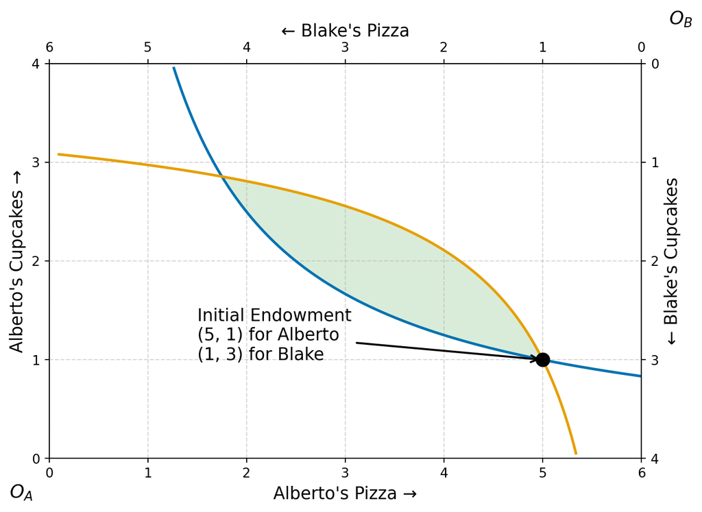

Is the current allocation **Pareto efficient**?

## Marginal Rate of Substitution (MRS)

What is the MRS for each of them at the initial endowment?

**Alberto**
$$MRS_A = \frac{0.5}{0.5} \cdot \frac{y_A}{x_A} = \frac{1 \cdot 1}{1 \cdot 5} = \frac{1}{5}$$

Alberto is willing to give up 1/5 of a cupcake for one more slice of pizza.

**Blake**

$$MRS_B = \frac{0.4}{0.6} \cdot \frac{y_B}{x_B} = \frac{2}{3} \cdot \frac{3}{1} = 2$$

Blake is willing to give up 2 cupcakes for one more slice of pizza.

## Contract Curve: Math

Set $MRS_A = MRS_B$:
$$\frac{0.5}{0.5} \cdot \frac{y_A}{x_A} = \frac{0.4}{0.6} \cdot \frac{y_B}{x_B}$$

Noting that $y_B = 4 - y_A$ and $x_B = 6 - x_A$, we can rewrite this as:
$$\frac{y_A}{x_A} = \frac{2}{3} \cdot \frac{4 - y_A}{6 - x_A}$$

Rearranging gives the equation of the contract curve:
$$3 y_A (6 - x_A) = 2 x_A (4 - y_A) \rightarrow y_A = \frac{8 x_A}{18 - x_A}$$

## The Contract Curve: Graph

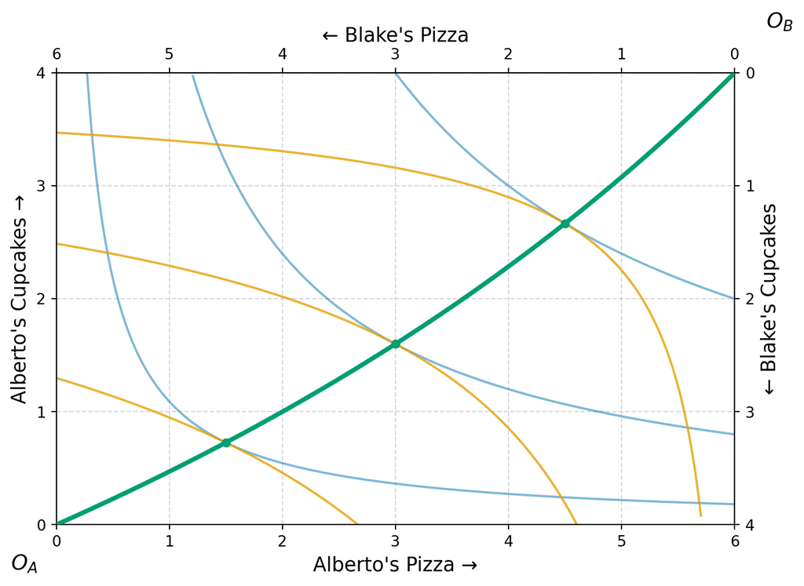

Which of the points get chosen?

## Equilibrium in a Competitive Market

- In a two person exchange, outcome will depend on relative bargaining power.
- In a competitive market, prices will guide them to a particular point on the contract curve.
- Think there are many Alberto-like and Blake-like consumers who are all price-takers.

**What should be the equilibrium prices?**

## Competitive Equilibrium

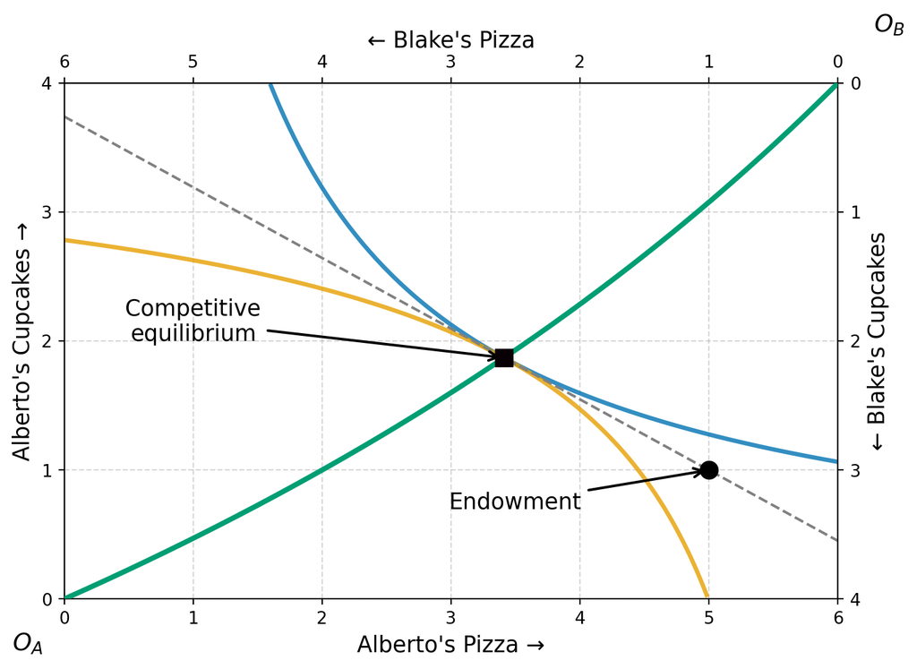

Why does the budget line pass through the endowment point?

## Competitive Equilibrium: Math

Normalize $p_y = 1$. Let $p_x = p$.

**Demands**:

$$x_A = \frac{0.5(5p_x + 1)}{p_x} \qquad y_A = 0.5(5p_x + 1)$$

$$x_B = \frac{0.4(p_x + 3)}{p_x} \qquad y_B = 0.6(p_x + 3)$$

**Market clearing for $y$:** $\quad y_A + y_B = 4$

$$0.5(5p_x + 1) + 0.6(p_x + 3) = 4 \rightarrow p_x \approx 0.55$$

Pizza is cheaper than cupcakes. Does that makes sense?

## Do it yourself!

**Two consumers, two goods ($x$ and $y$)**

- **Carmen** has endowment $(4, 0)$ and utility $U_C = x^{1/2} y^{1/2}$
- **Diego** has endowment $(0, 4)$ and utility $U_D = x^{1/2} y^{1/2}$

Normalize $p_y = 1$. Find:

1. Each person’s demand functions for $x$ and $y$
2. The equilibrium price $p_x$
3. The equilibrium allocation
4. Verify that markets clear

Is the equilibrium Pareto efficient? How do you know?

> “Capitalism is the astounding belief that the most wickedest of men will do the most wickedest of things for the greatest good of everyone.”

— John Maynard Keynes

## First Welfare Theorem

**First Welfare Theorem:** If every consumer is locally nonsatiated and $(x^*, p^*)$ is a competitive (Walrasian) equilibrium, then $x^*$ is Pareto efficient.

**Local nonsatiation:** For any bundle, there is always a nearby bundle the consumer strictly prefers. This just rules out “thick” indifference curves and ensures consumers spend their entire budget.

**What it says:** Markets with price-taking behavior and no externalities produce efficient outcomes. No one can be made better off without making someone else worse off.

**What it does NOT say:** Nothing about fairness, equity, or whether the outcome is socially desirable.

## Proof of the First Welfare Theorem

Suppose $(x^*, p^*)$ is a competitive equilibrium but **not** Pareto efficient. Then there exists an allocation $\hat{x}$ such that:

- $\hat{x}_i \succeq x_i^*$ for all $i$, with strict preference for some $i$

**Step 1:** If consumer $i$ strictly prefers $\hat{x}_i$ to $x_i^*$, then $\hat{x}_i$ must cost more than $i$’s income (otherwise $i$ would have chosen it):
$$p^* \cdot \hat{x}_i > p^* \cdot \omega_i$$

**Step 2:** If consumer $j$ weakly prefers $\hat{x}_j$, local nonsatiation implies:
$$p^* \cdot \hat{x}_j \geq p^* \cdot \omega_j$$

## Proof (cont.)

**Step 3:** Summing over all consumers:
$$p^* \cdot \sum_i \hat{x}_i > p^* \cdot \sum_i \omega_i$$

But feasibility requires $\sum_i \hat{x}_i \leq \sum_i \omega_i$. **Contradiction.** $\quad \blacksquare$

## What Makes This Remarkable

The theorem requires almost nothing:

- No assumptions about convexity of preferences
- No assumptions about the number of goods or consumers
- Works for any number of goods and any number of people
- Only needs local nonsatiation and price-taking behavior

**Adam Smith’s invisible hand, formalized:** Decentralized decisions by self-interested agents, coordinated only by prices, produce an outcome that no central planner could improve upon (in the Pareto sense).

## Equity vs. Efficiency

Suppose society prefers a more equitable allocation. Can we achieve it without sacrificing efficiency?

**Naive approach:** Price controls, rationing, direct mandates → typically create deadweight loss

**Better question:** Is there a way to use the power of markets (which we know produce efficient outcomes) to reach any desired efficient allocation?

This is exactly what the Second Welfare Theorem answers.

## Second Welfare Theorem

**Statement:** If preferences are convex and locally nonsatiated, then any Pareto efficient allocation $x^*$ can be supported as a competitive equilibrium with appropriate lump-sum transfers.

**Translation:** Pick any point on the contract curve. There exists a redistribution of endowments and a price vector such that $x^*$ is the resulting competitive equilibrium.

**Stronger assumptions than the First Theorem:** Now we need convexity of preferences (diminishing MRS). Without convexity, the supporting price line may not be tangent to both indifference curves simultaneously.

## Second Welfare Theorem: Graphically

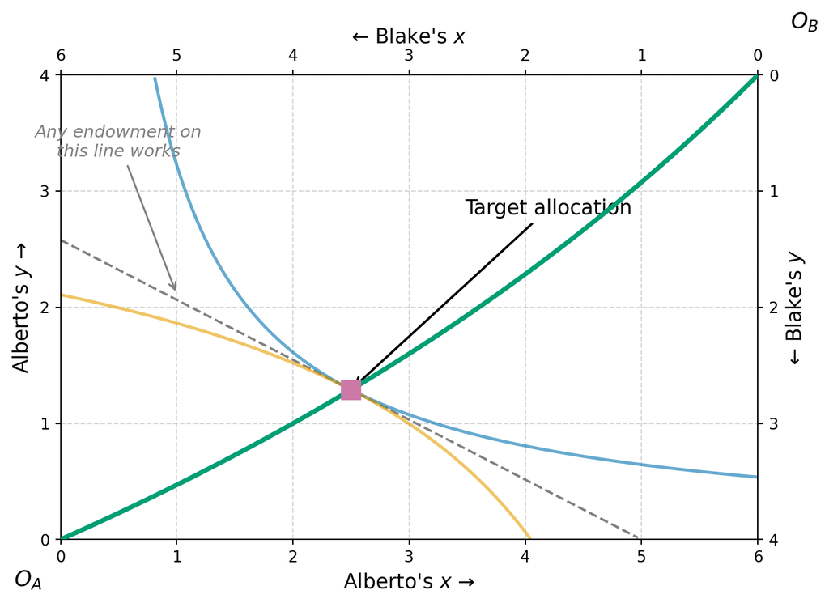

Pick any Pareto efficient allocation. Redistribute endowments to a point on the supporting price line, then let markets work.

## Implications for Policy

The two theorems together give a powerful separation:

**First Welfare Theorem:** Markets handle *efficiency* — let prices allocate resources

**Second Welfare Theorem:** Government handles *equity* — use lump-sum transfers to adjust the starting point

**The policy recipe:**

1. Redistribute endowments (lump-sum taxes and transfers)
2. Then let competitive markets do the rest

**Why this is hard in practice:** True lump-sum transfers are almost impossible. Any tax that depends on behavior (income, consumption, wealth) distorts incentives and creates deadweight loss. This tension between equity and efficiency is at the heart of public economics.

# Social Welfare Functions

## Which Efficient Allocation Is Best?

The welfare theorems tell us about efficiency, but there are infinitely many Pareto efficient allocations. How does society choose among them?

We need a way to aggregate individual wellbeing into a social ranking. Enter the **social welfare function:**

$$W = W(U_1, U_2, \ldots, U_n)$$

This maps individual utilities into a single measure of social welfare. Different functional forms encode different ethical positions about inequality and the tradeoff between people’s interests.

## Common Social Welfare Functions

**Utilitarian (Bentham):**
$$W = \sum_{i=1}^n U_i$$
Maximize total utility. Treats a dollar to a rich person and a dollar to a poor person equally.

**Weighted utilitarian:**
$$W = \sum_{i=1}^n a_i U_i, \quad a_i > 0$$
Society may value some individuals’ utility more (e.g., higher weight on the worst-off).

## Common Social Welfare Functions (cont.)

**Rawlsian (maximin):**
$$W = \min\{U_1, U_2, \ldots, U_n\}$$
Maximize the utility of the worst-off person. Extreme inequality aversion.

**Nash (product):**
$$W = \prod_{i=1}^n U_i$$
Equivalent to maximizing $\sum \ln U_i$. Intermediate inequality aversion.

## Social Indifference Curves

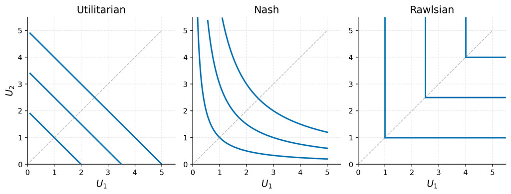

The shape of social indifference curves reflects how much society is willing to trade off one person’s utility for another’s. Dashed line is the 45° line (perfect equality).

## Choosing an Allocation

The social planner maximizes $W(U_1, U_2)$ subject to the constraint that the allocation is feasible.

In the Edgeworth box, this means choosing the point on the **utility possibilities frontier** (derived from the contract curve) that reaches the highest social indifference curve.

Different social welfare functions pick different points:

- **Utilitarian** → may tolerate significant inequality if total utility is higher
- **Rawlsian** → always picks the most equal feasible outcome
- **Nash** → something in between

**Arrow’s impossibility theorem** (1951) tells us there is no “right” answer — any SWF encodes value judgments that cannot be derived from individual preferences alone.

# Adding Production

## Beyond Exchange

So far, the total quantities of $x$ and $y$ were fixed. In reality, society also decides **how much of each good to produce**.

Adding production introduces a new margin of efficiency: not just *how to allocate goods* (exchange efficiency), but also *how to allocate inputs across industries* (production efficiency) and *what mix of goods to produce* (product-mix efficiency).

The key new object is the **production possibilities frontier** (PPF).

## Production Possibilities Frontier

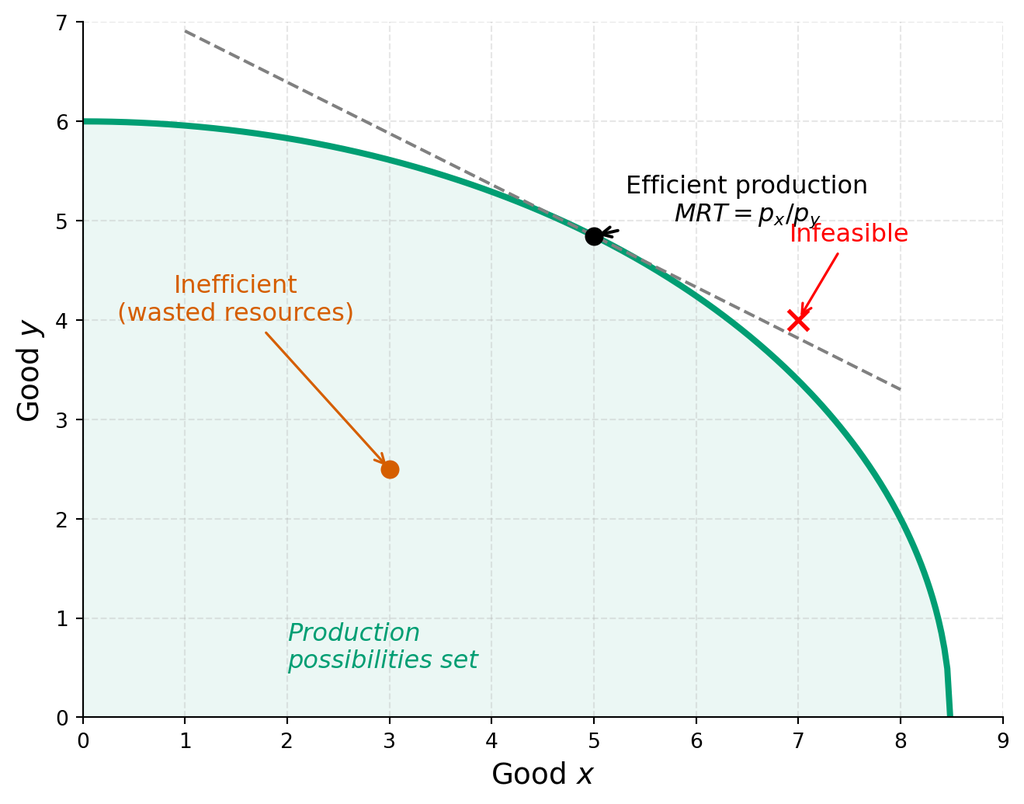

The PPF shows all efficient combinations of output given the economy’s resources and technology. Its slope is the **marginal rate of transformation** (MRT).

## Three Conditions for Overall Efficiency

**1. Exchange efficiency** (as before):
$$MRS_A = MRS_B$$
No gains from trading goods between consumers.

**2. Production efficiency:**
$$MRTS_x = MRTS_y$$
No gains from reallocating inputs between industries. This puts us *on* the PPF.

**3. Product-mix efficiency:**
$$MRS = MRT$$
The rate at which consumers are willing to trade $x$ for $y$ equals the rate at which the economy *can* transform $x$ into $y$.

## Competitive Equilibrium with Production

**Competitive equilibrium achieves all three** because:

- Consumers set $MRS = p_x/p_y$
- Firms set $MRTS = w/r$ (same factor prices)
- Profit-maximizing firms produce where $MRT = p_x/p_y$

## The Complete Picture

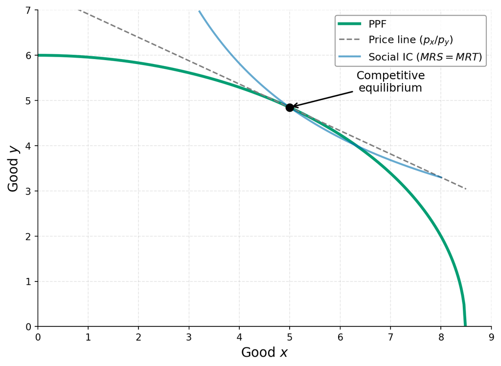